# Lab 2: Visualizing Categorical and Quantitative Data

### Loading Data

A first step to any good R session is to set your working directory. This is the directory you will be loading your data from and potentially saving your output (figures and summary tables) into.

```r
setwd("C:/Users/micha/Dropbox/classes/statr501 fall 2016/week2/data")
```

(NOTE: this can be done using point and click windows in Rstudio)

Copy the data files from Week 2 into whatever folder you’ve set as your working directory.

We will start by loading the student survey data:

```r
Students <- read.csv("StudentSurvey.csv")
```

### Working with data frames

Look at some properties of this data file, with the following functions:

```r
is(Students)
```

```
## [1] "data.frame" "list"       "oldClass"   "vector"
```

```r
dim(Students)
```

```
## [1] 94 15
```

```r
names(Students)
```

```
##  [1] "Sex"      "Age"      "Height"   "Weight"   "Shoe"     "Handed"
##  [7] "Country"  "Hair"     "Eyes"     "Sleep"    "Study"    "Online"
## [13] "Outside"  "Math"     "Pingpong"
```

```r
head(Students)
```

```
##      Sex Age Height Weight Shoe Handed     Country   Hair  Eyes Sleep
## 1   Male  28     60    170 10.0      R South Korea Black  Brown     7
## 2 Female  19     54    120  7.5      R         USA  Brown  Blue     7
## 3 Female  20     57    115  6.0      R         USA  Black Brown     7
## 4 Female  20     60    143  6.0      R  Bangladesh Black  Black     7
## 5 Female  19     60    110  6.0      R   Singapore  Black Black     6
## 6 Female  20     61    105  7.0      R     Vietnam Black  Brown     6
##   Study Online Outside                    Math Pingpong
## 1   3.0      0       5 Think it's kind of cool        2
## 2   2.0      6       5    Don't think about it        3
## 3   0.0      0    8~10             Tolerate it        1
## 4   0.5      2       3             Tolerate it        1
## 5   0.0      2       3   I live and breathe it        5
## 6   0.0      2       1 Think it's kind of cool        2
```

```r
str(Students)
```

```
## 'data.frame':    94 obs. of  15 variables:
##  $ Sex     : Factor w/ 2 levels "Female","Male": 2 1 1 1 1 1 1 1 1 1 ...
##  $ Age     : int  28 19 20 20 19 20 20 21 20 19 ...
##  $ Height  : num  60 54 57 60 60 61 61 62 63 63 ...
##  $ Weight  : int  170 120 115 143 110 105 110 108 90 90 ...
##  $ Shoe    : num  10 7.5 6 6 6 7 6 6.5 6.5 5.5 ...
##  $ Handed  : Factor w/ 2 levels "L","R": 2 2 2 2 2 2 2 2 2 2 ...
##  $ Country : Factor w/ 15 levels "Australia","Austria",..: 12 14 14 3 11 15 14 5 5 5 ...
##  $ Hair    : Factor w/ 10 levels "Black","Black ",..: 2 5 1 2 1 2 4 2 2 2 ...
##  $ Eyes    : Factor w/ 10 levels "Black","Blue",..: 4 2 4 1 1 4 2 1 1 1 ...
##  $ Sleep   : num  7 7 7 7 6 6 8.5 8 7 8 ...
##  $ Study   : num  3 2 0 0.5 0 0 1 0 3 3 ...
##  $ Online  : Factor w/ 14 levels "0","0.2","0.5",..: 1 12 1 6 6 6 6 8 8 4 ...
##  $ Outside : Factor w/ 22 levels "<1","0","0.5",..: 15 15 20 13 13 4 4 2 19 14 ...
##  $ Math    : Factor w/ 6 levels "Despise it","Don't think about it",..: 5 2 6 6 3 5 6 4 4 NA ...
##  $ Pingpong: int  2 3 1 1 5 2 1 1 1 3 ...
```

Note, the `str()` command (for structure) gives you the most detailed information. It is overkill for a data frame, but useful when you deal with more complex objects.

In order to extract a column from a data frame, you can either reference its number (as with a matrix), such as `Students[,4]` or use the much more useful - and generally better practice - `$` and column name operator:

```r
Country <- Students$Country
```

### Summarizing the Country data

Check out what `Country` is:

```r
is(Country)
```

```
## [1] "factor"              "integer"             "oldClass"
## [4] "numeric"             "vector"              "data.frameRowLabels"
```

Now that we have the categorical data, encoded as a factor (the default way in which R interprets a character string when loading data from a text file). Make a summary table:

```r
table(Country)
```

```
## Country
##   Australia     Austria  Bangladesh     Belgium       China   Hong Kong
##           1           1           1           1          28           1
##       Japan       Macau    Malaysia      Russia   Singapore South Korea
##           3           1           1           1           2           6
##      Taiwan         USA     Vietnam
##           7          37           2
```

Draw a barplot

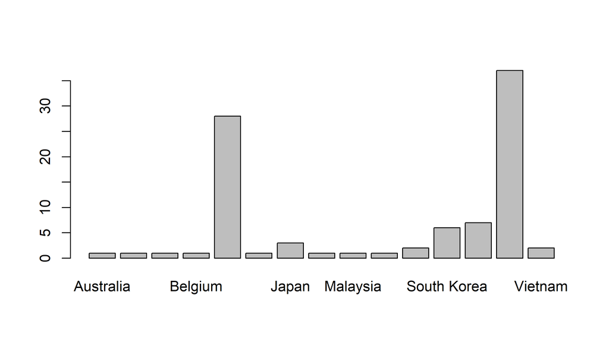

```r
barplot(table(Country))
```

Draw a sorted barplot

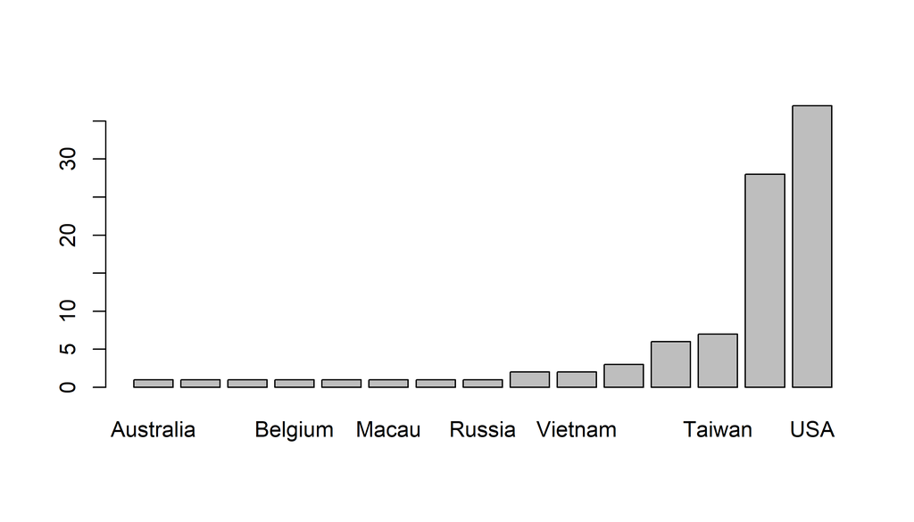

```r
barplot(sort(table(Country)))
```

*Quickie Exercise:* **Figure out how to draw a barplot with decreasing frequencies.**

### Tweaking the bar plot

Note that we cannot really read the x-axis because the country names are so long. We need to tweak this plot in a couple of ways: (1) make the country names vertical and (2) make the lower margins larger.

The motherlode of all plot tweaks is in the “par()” function, which sets all graphical parameters. These settings remain until they are changed or until the graphics device is “renewed”. You will spend much time poking around in the help file of par()!

A few examples: `las` sets the orientation of labels, `mar` sets the margin sizes (think about what the four numbers refer to).

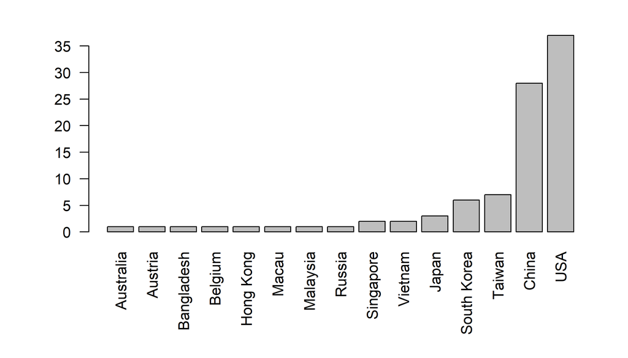

```r
par(las = 2, mar=c(7,5,2,2))
barplot(sort(table(Country)))
```

Label the y-axis

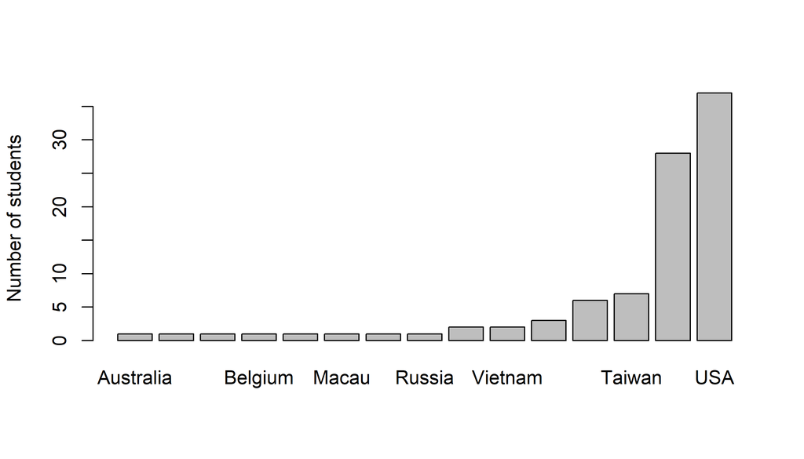

```r
barplot(sort(table(Country)), ylab="Number of students")
```

or add colors

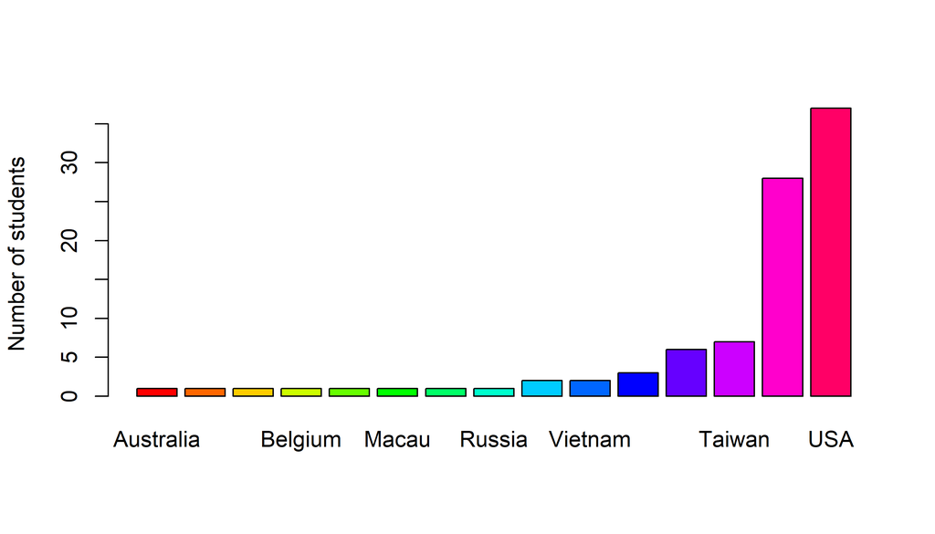

```r
barplot(sort(table(Country)), ylab="Number of students", col=rainbow(15))
```

### Exporting Graphics

There are several good ways to export graphics, like: `pdf()` or `jpeg()` or `png()` or `tiff()` or `bmp()`. Each of these functions has its own ways to set the size, resolution, etc.

I personally like making `.pdf`’s - because they are vector graphics and therefore the resolution is effectively infinite. Also, I compile all my documents directly in pdf format. But they are more difficult to incorporate into, e.g., Word or Powerpoint documents.

The initial command opens a new graphics device (with the specified name)

```r
pdf("StudentBarplot.pdf")
  # you have to redefine your graphical parameter for this new "device"
  par(las = 2, mar=c(7,5,2,2))
  barplot(sort(table(Country)), ylab="Number of students", col=rainbow(15))
dev.off()
# this last command closes the graphics device.
```

### Exporting data frames to a file

Save the summary table as a data frame

```r
  Country.df <- data.frame(table(Country))
```

We can save this useful summary table to the computer as follows:

```r
  write.csv(Country.df, file="CountrySummaryTable.csv")
```

We can analyze these data by sex as well. Subset the country data into two data frames: males and females

```r
  Students.M <- Students[Students$Sex == "Male",]
  Students.F <- Students[Students$Sex == "Female",]
  Country.M <- Students.M$Country
  Country.F <- Students.F$Country

  Country.df <- data.frame(table(Country.M), table(Country.F), table(Country))
```

This is a slightly awkward looking table.

```r
  Country.df <- data.frame(table(Country),
                Female = as.vector(table(Country.F)),
                Male = as.vector(table(Country.M)))
```

Rename the Totals column.

```r
  names(Country.df)[2] <- "Total"
  write.csv(Country.df, file="CountrySummaryTable2.csv")
```

Lets say we want to make a good visual comparison of the proportions by country of males and females. First, break the graphics device into two windows

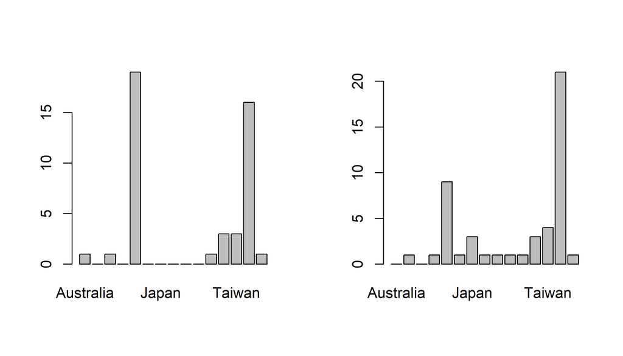

```r
  par(mfrow = c(1,2))
  barplot(table(Country.F))
  barplot(table(Country.M))
```

Note that the all-important (if mysteriously named `mfrow`) argument works by taking a vector with two elements: the number of rows, and the number of columns in the layout

Here’s a version with horizontal bars

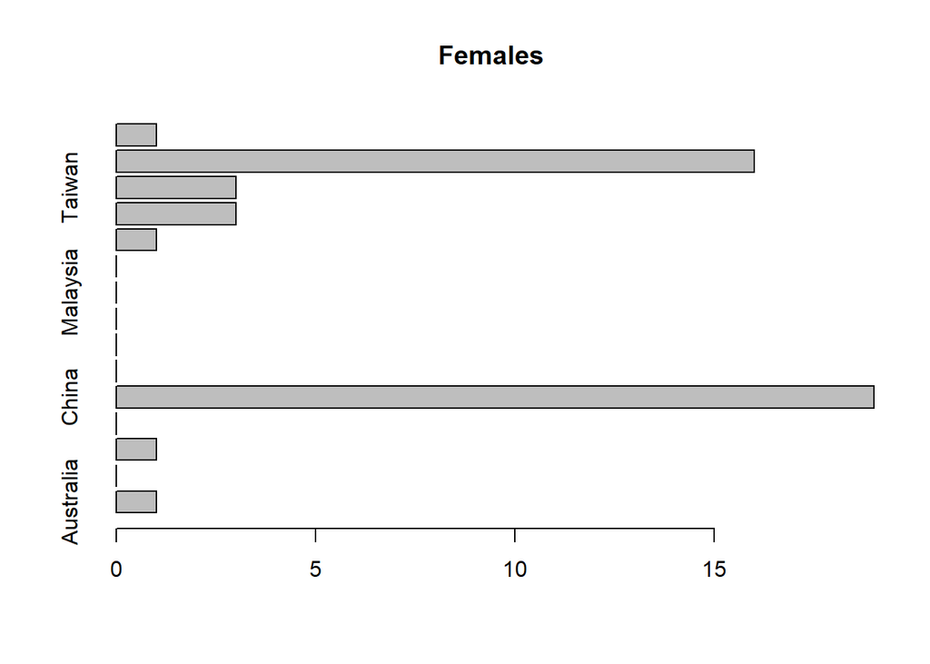

```r
  barplot(table(Country.F), horiz=TRUE, main="Females")
```

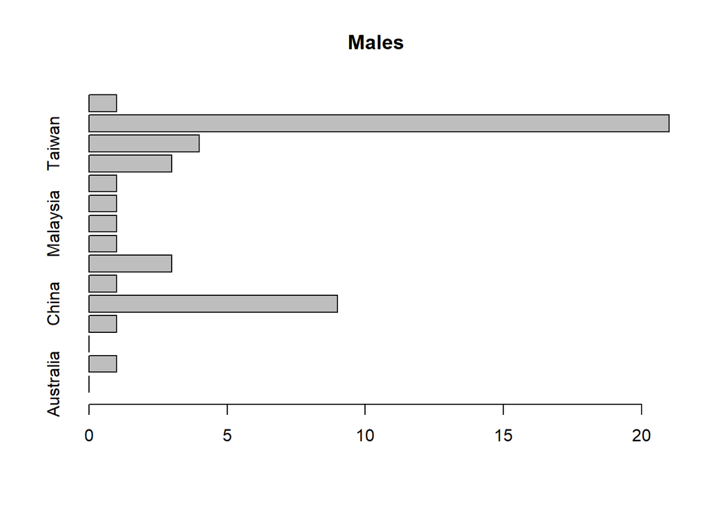

```r
  barplot(table(Country.M), horiz=TRUE, main="Males")
```

Here’s a version with horizontal bars, where we tricked the barplots

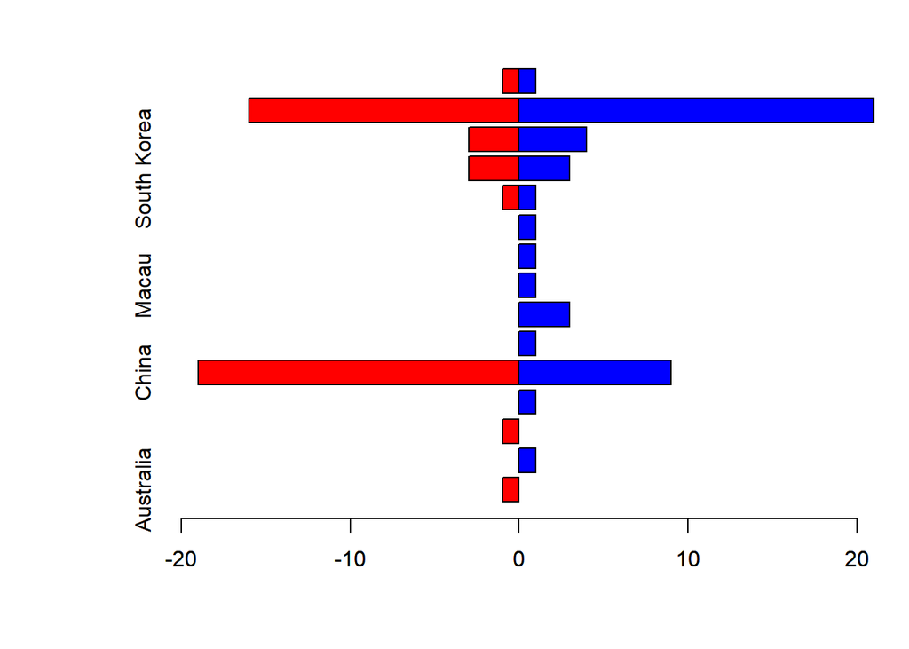

```r
  par(mfrow = c(1,1), mar=c(5,7,2,2))
  barplot(-table(Country.F), horiz=TRUE, yaxt="n", xlim=c(-20,20), col="red")
  barplot(table(Country.M), horiz=TRUE, add=TRUE, col="blue")
```

The plot can keep being improved in countless ways, but you get the idea.

Exercise: Read about the `text()` function, and see if can figure out a way to label the two sides of this figure with “Female” and “Male” tags.

### More on factors

Note that “Country” is a factor

```r
  is(Country)
```

```
## [1] "factor"              "integer"             "oldClass"
## [4] "numeric"             "vector"              "data.frameRowLabels"
```

```r
  levels(Country)
```

```
##  [1] "Australia"   "Austria"     "Bangladesh"  "Belgium"     "China"
##  [6] "Hong Kong"   "Japan"       "Macau"       "Malaysia"    "Russia"
## [11] "Singapore"   "South Korea" "Taiwan"      "USA"         "Vietnam"
```

Note that the “levels” of Country are alphabetical. We can reorder the levels to reflect the frequencies.

```r
  levels.ordered <- names(sort(table(Country)))
```

this is a character vector of the ordered levels, which we use to “recreate” Country.

```r
  Country <- factor(Country, levels=levels.ordered)
  levels(Country)
```

```
##  [1] "Australia"   "Austria"     "Bangladesh"  "Belgium"     "Hong Kong"
##  [6] "Macau"       "Malaysia"    "Russia"      "Singapore"   "Vietnam"
## [11] "Japan"       "South Korea" "Taiwan"      "China"       "USA"
```

Now, if we recreate our vectors, the figure from above will be comparable

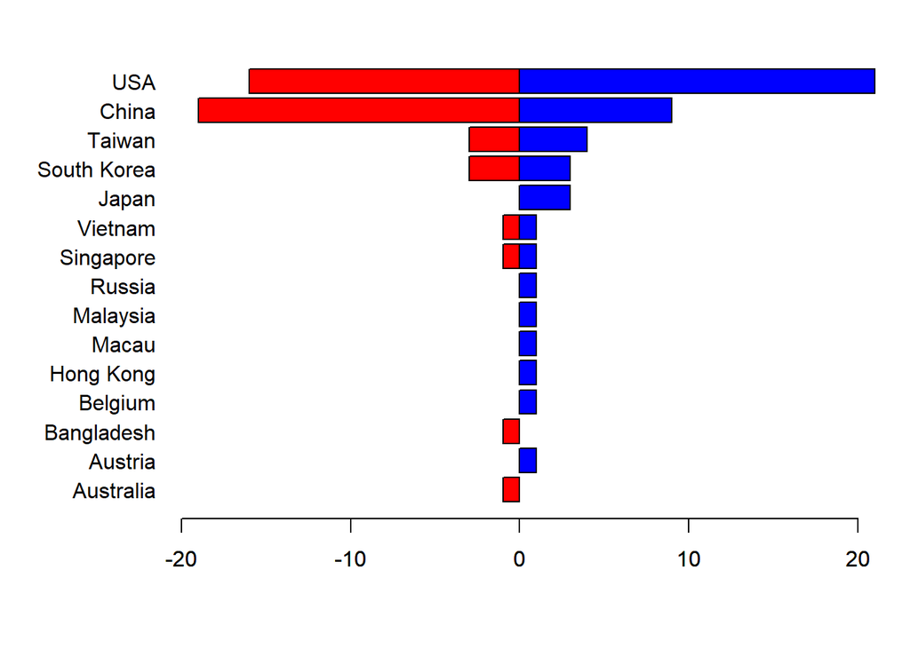

```r
  Country.M <- Country[Students$Sex == "Male"]
  Country.F <- Country[Students$Sex == "Female"]
  par(mfrow = c(1,1), mar=c(5,7,2,2), las=1)
  barplot(-table(Country.F), horiz=TRUE, yaxt="n", xlim=c(-20,20), col="red")
  barplot(table(Country.M), horiz=TRUE, add=TRUE, col="blue")
```

### Part 2: Quantitative Data

Load the sea lion pup data set:

```r
    Pups <- read.csv("PupTaggingData.csv")
    dim(Pups)
```

```
## [1] 498  10
```

```r
    head(Pups)
```

```
##     Island TaggingDate     ID Weight Length Girth       BCI Sex Age  DOB
## 1 Chirpoev   7/10/2005 Br800L   15.5     93  69.0 0.7419355   M  NA <NA>
## 2 Chirpoev   7/10/2005 Br801L   29.0    106  71.0 0.6698113   F  NA <NA>
## 3 Chirpoev   7/10/2005 Br802L   35.5    112  76.0 0.6785714   M  NA <NA>
## 4 Chirpoev   7/10/2005 Br803L   32.0    107  72.0 0.6728972   M  NA <NA>
## 5 Chirpoev   7/10/2005 Br804L   32.0    105  73.5 0.7000000   M  NA <NA>
## 6 Chirpoev   7/10/2005 Br805L   33.5    111  72.0 0.6486486   M  NA <NA>
```

Use the table function to make a quick table of number of pups by Island and Sex

```r
    table(Pups$Island, Pups$Sex)
```

```
##
##               F  M
##   Antsiferov 38 62
##   Chirpoev   43 56
##   Lovushki   50 50
##   Raykoke    49 51
##   Srednova   46 53
```

Extract the weight, girth, length, sex, and island vectors

```r
    Length <- Pups$Length
    Weight <- Pups$Weight
    Girth <- Pups$Girth
    Sex <- Pups$Sex
    Island <- Pups$Island
```

Note that this is tedious and bad practice. We should leave the data in the data.frame.

```r
    rm(Length, Weight, Girth, Sex, Island)
```

An alternative is the “attach()” function, which does magic involvinv environments to make these variables accessible in the global environment.

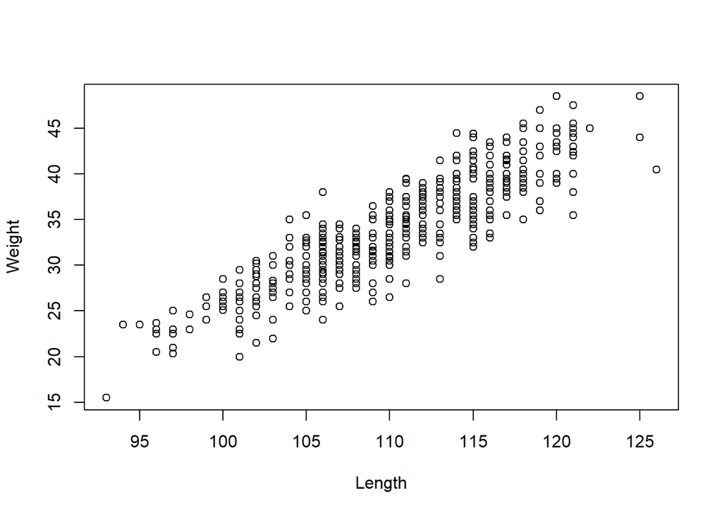

```r
    rm(list=ls())   # removes all objects in memory
    Pups <- read.csv("PupTaggingData.csv")
    attach(Pups)
    plot(Length, Weight)
```

Generally, it is bad practice to use “attach()”.

```r
    detach(Pups)
```

It’s better to refer to variables using subsetting. ie. `Pups$Length` even if that’s a bit harder to type.

### Histograms

The basic function:

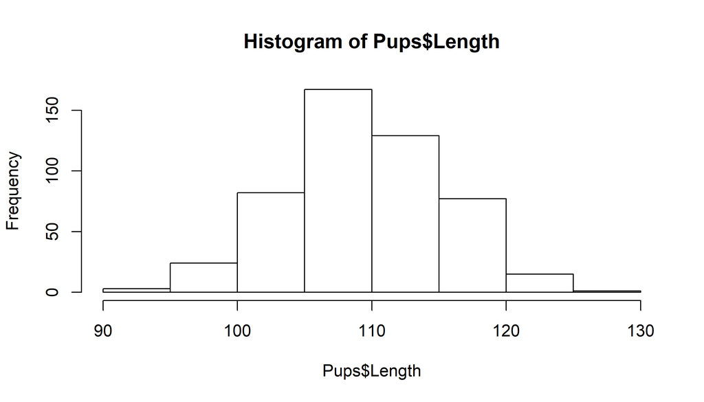

```r
    hist(Pups$Length)
```

Note, the coarse binning. We can increase the number of bins.

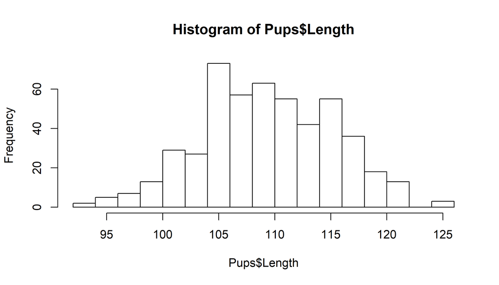

```r
    hist(Pups$Length, breaks=20)
```

or, with more control, strictly set the number of bins

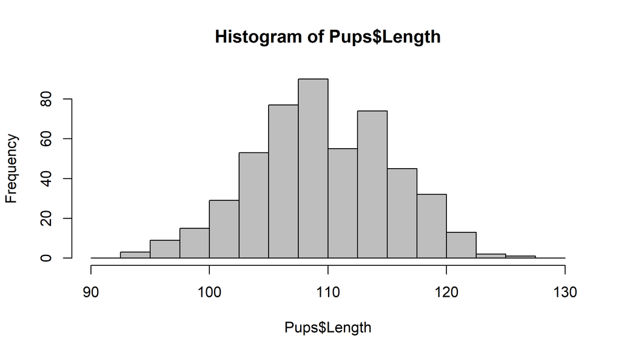

```r
    hist(Pups$Length, breaks=seq(90,130,2.5), col="grey")
```

or, with more generality:

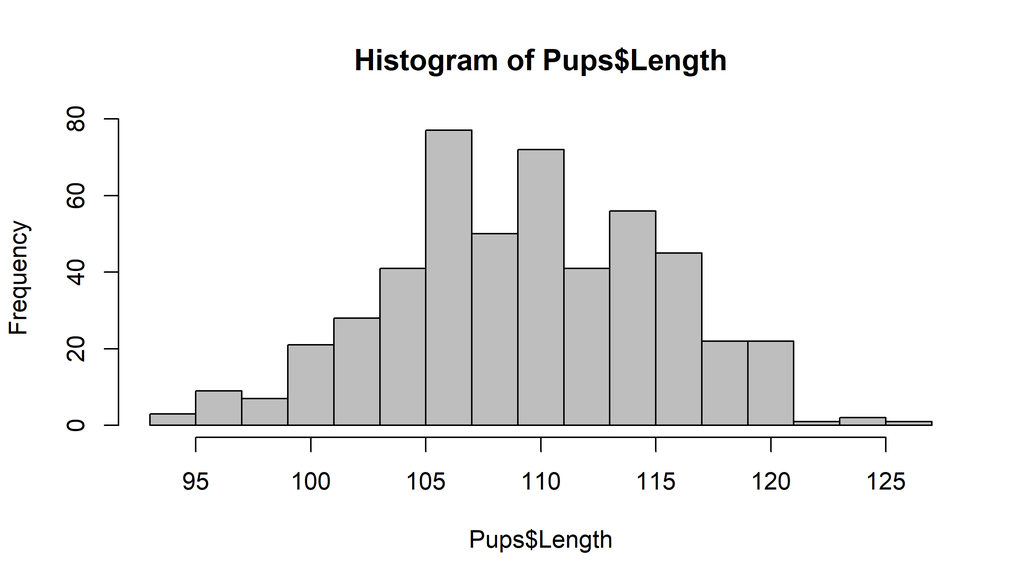

```r
    mybreaks <- seq(floor(min(Pups$Length)),ceiling(max(Pups$Length))+2, 2)
    hist(Pups$Length, breaks=mybreaks, col="grey")
```

Lets compare males and females:

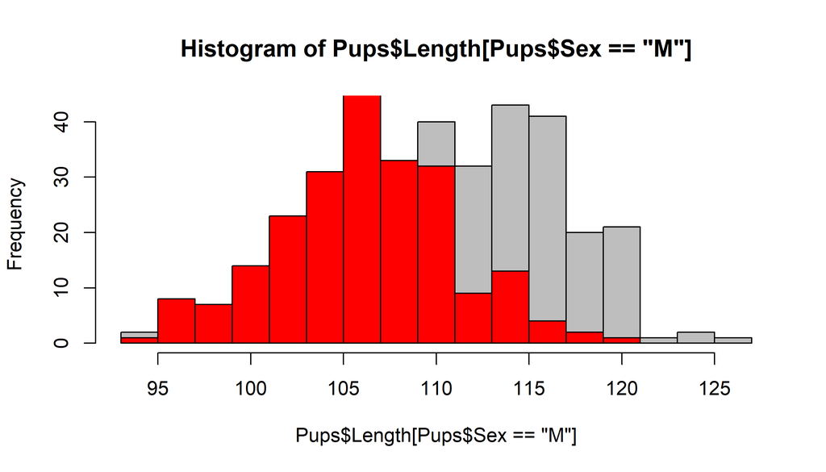

```r
    hist(Pups$Length[Pups$Sex=="M"], breaks=mybreaks, col="grey")
    hist(Pups$Length[Pups$Sex=="F"], breaks=mybreaks, col="red", add=TRUE)
```

Note the “add = TRUE” parameter, which does not generate a new histogram every time.

It is hard to see what is going on here because of the overlap! We use transparent colors with `rgb()`

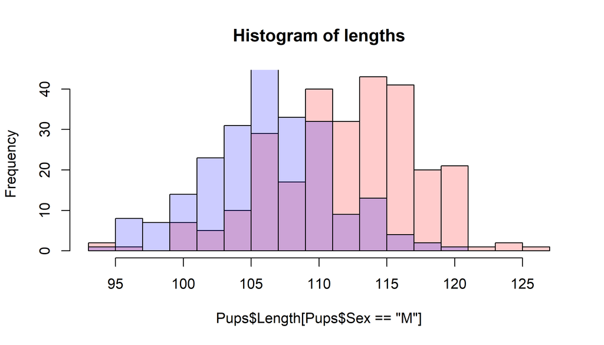

```r
    hist(Pups$Length[Pups$Sex=="M"], breaks=mybreaks, col=rgb(1,0,0,.2), main="Histogram of lengths")
    hist(Pups$Length[Pups$Sex=="F"], breaks=mybreaks, col=rgb(0,0,1,.2), add=TRUE)
```

and many additional tweaks are possible.

### Density curves

We can add density curve to a histogram as well

```r
Length.density <- density(Pups$Length)
```

this is a density plot

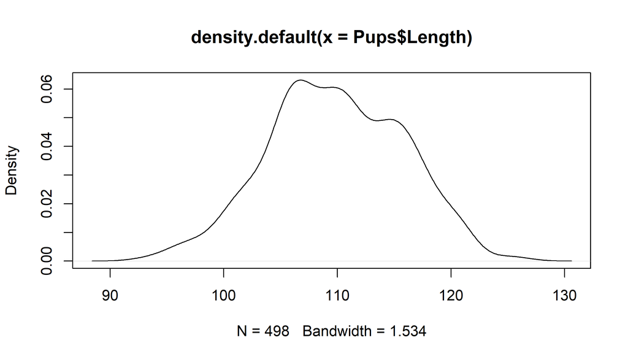

```r
    plot(Length.density)
```

Note that “plot” draws different objects in very specific ways. That is because it is what we call a *generic* method. You can add the density line to a histogram

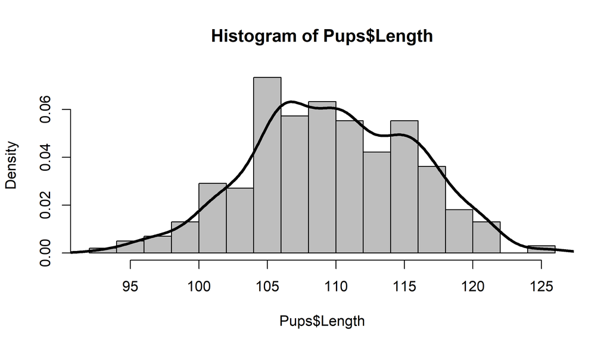

```r
    hist(Pups$Length, breaks = 20, freq=FALSE, col="grey")
    lines(Length.density, lwd=3)
```

In class, we created a customized function for generating a histogram:

```r
    MyHist <- function(X, xlab, binwidth)
    {
      hist(X,
           breaks =
             seq(min(floor(X)), max(ceiling(X)), binwidth),
           col=rgb(.5,0,1,.5), xlab = xlab)
    }
```

### EXERCISE

Produce a plot with three windows (using `par(mfrow=c(1,3))`) which draws overlapping histograms of pup weight, length and girth for males and females. Add density lines.

this works:

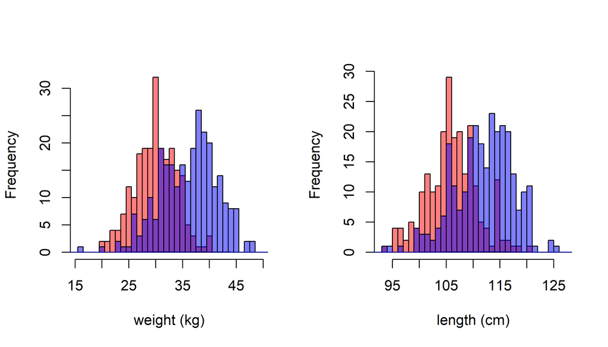

```r
  par(mfrow=c(1,2))
  MyDoubleHist(Pups$Weight, xlab="weight (kg)")
  MyDoubleHist(Pups$Length, xlab="length (cm)")
```

but this doesn’t work!

```r
    MyDoubleHist(Pups$Girth, xlab="girth (cm)")
```

```
## Error in seq.default(min(X), max(X) + binwidth, binwidth): 'from' cannot be NA, NaN or infinite
```

This is our first encounter with the dreaded NA!

Note that when we try to calculate the max and min of Girth we get “NA”:

```r
max(Pups$Girth); min(Pups$Girth)
```

```
## [1] NA
```

```
## [1] NA
```

This is gumming up out generation of the bins. To fix this, we need to add `na.rm = TRUE` to those calculations. Note also that in this version we present density histograms and add density lines.

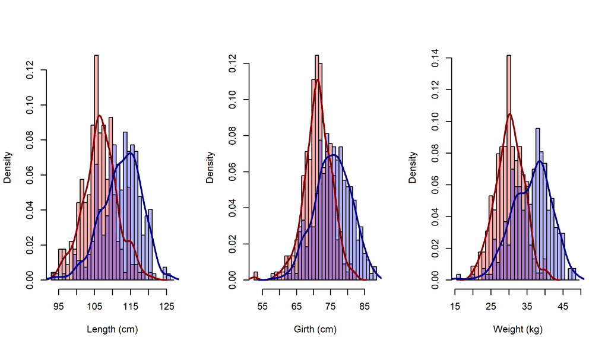

```r
  MyDoubleHist2 <- function(X, xlab="", main = "", binwidth = 1)
  {
    X.F <- X[Pups$Sex=="F"]
    X.M <- X[Pups$Sex=="M"]

    hist(X.F, freq=FALSE,
         breaks = seq(min(X, na.rm=TRUE), max(X, na.rm=TRUE) + binwidth, binwidth),
         col=rgb(1,0,0,.3), xlab = xlab, main=main)
    hist(X.M, freq=FALSE,
         breaks = seq(min(X, na.rm=TRUE), max(X, na.rm=TRUE) + binwidth, binwidth),
         col=rgb(0,0,1,.3), add=TRUE)
    lines(density(X.F, na.rm=TRUE), col="darkred", lwd=2)
    lines(density(X.M, na.rm=TRUE), col="darkblue", lwd=2)
  }

  par(mfrow=c(1,3))
  MyDoubleHist2(Pups$Length, "Length (cm)")
  MyDoubleHist2(Pups$Girth, "Girth (cm)")
  MyDoubleHist2(Pups$Weight, "Weight (kg)")
```

I think this looks pretty darned good!